# Iowa City Data Representation

Aaron Jencks

4/27/2020

## Data Cleaning

```r
# Eliminate outliers
crash_data = crash_data %>% filter(X > -92 & Y < 42 & Y > 41.25)

# Update the vehicle data
crash_vehicle_data = crash_vehicle_data %>% filter(X > -91.9 & X < -91.45 & Y < 41.875 & Y > 41.4 & VEH_CRASH_KEY %in% unique(crash_data$CRASH_KEY))

# Fix datatypes
crash_data = crash_data %>%
    mutate(CRASH_DATE = as_datetime(as.character(CRASH_DATE)),
        LECASENUM = as.numeric(LECASENUM),
        LITERAL = as.character(LITERAL),
        DRUGALC = factor(DRUGALC, levels=rev(c('None Indicated', 'Refused',
            'Alcohol (<Statutory)', 'Drug/Alcohol (< Statutory)',
            'Drug',
            'Alcohol (Statutory)', 'Drug/Alcohol (Statutory)',
            'Under Influence of Alcohol/Drugs/Medications')))) %>%
    select(-X.1, -OBJECTID,
        -CITY_NUMBER, -DISTRICT, -COUNTY_NUMBER, -XCOORD, -YCOORD,
        -CITY_NAME, -COUNTY_NAME,
        -CRASH_DATETIME, -CRASH_DATETIME_UTC, -CRASH_DATETIME_UTC_OFFSET, -REST_UPDATED, -REST_UPDATE_UTC_OFFSET,
        -CARDINAL, -GLOBALID)

crash_vehicle_data = crash_vehicle_data %>%
    mutate(CRASH_DATETIME = as_datetime(as.character(CRASH_DATETIME))) %>%
    select(-CRASH_DATETIME_UTC, CRASH_DATETIME_UTC_OFFSET, -REST_UPDATED, -REST_UPDATED_UTC_OFFSET, -GLOBALID)

# Fix dates
crash_data = crash_data %>%
    separate(CRASH_DATE, c('year', 'month', 'day')) %>% select(-month) %>% mutate(year = as.numeric(year), day = as.numeric(day)) %>%
    separate(TIMESTR, c('hour', 'minute')) %>% mutate(hour = as.numeric(hour), minute = as.numeric(minute))

crash_vehicle_data = crash_vehicle_data %>% mutate(year = year(CRASH_DATETIME), month = month(CRASH_DATETIME), day = day(CRASH_DATETIME),
    hour = hour(CRASH_DATETIME), minute = minute(CRASH_DATETIME)) %>% select(-CRASH_DATETIME)

# Fixing car make names

levels(crash_vehicle_data$MAKE)[levels(crash_vehicle_data$MAKE) == 'ACAT'] = 'CAT'

levels(crash_vehicle_data$MAKE)[levels(crash_vehicle_data$MAKE) == 'Acur' |
    levels(crash_vehicle_data$MAKE) == 'ACUR'] = 'Acura'

levels(crash_vehicle_data$MAKE)[levels(crash_vehicle_data$MAKE) == 'AUDI'] = 'Audi'

levels(crash_vehicle_data$MAKE)[levels(crash_vehicle_data$MAKE) == 'BIGD'] = 'BIG'

levels(crash_vehicle_data$MAKE)[levels(crash_vehicle_data$MAKE) == 'BLUE'] = 'Blue'

levels(crash_vehicle_data$MAKE)[levels(crash_vehicle_data$MAKE) == 'BUIC' |
    levels(crash_vehicle_data$MAKE) == 'Buic'] = 'Buick'

levels(crash_vehicle_data$MAKE)[levels(crash_vehicle_data$MAKE) == 'Cadi' |
    levels(crash_vehicle_data$MAKE) == 'Cagi' |
    levels(crash_vehicle_data$MAKE) == 'CADI'] = 'Cadillac'

levels(crash_vehicle_data$MAKE)[levels(crash_vehicle_data$MAKE) == 'CAPA'] = 'Capa'

levels(crash_vehicle_data$MAKE)[levels(crash_vehicle_data$MAKE) == 'Chev' |
    levels(crash_vehicle_data$MAKE) == 'CHEV'] = 'Chevrolet'

levels(crash_vehicle_data$MAKE)[levels(crash_vehicle_data$MAKE) == 'Chry' |
    levels(crash_vehicle_data$MAKE) == 'CHRY'] = 'Chrysler'

levels(crash_vehicle_data$MAKE)[levels(crash_vehicle_data$MAKE) == 'Dodg' |
    levels(crash_vehicle_data$MAKE) == 'DODG' |
    levels(crash_vehicle_data$MAKE) == 'RAM' |
    levels(crash_vehicle_data$MAKE) == 'Ram'] = 'Dodge'

levels(crash_vehicle_data$MAKE)[levels(crash_vehicle_data$MAKE) == 'DUCA'] = 'Duca'

levels(crash_vehicle_data$MAKE)[levels(crash_vehicle_data$MAKE) == 'Eagl' |
    levels(crash_vehicle_data$MAKE) == 'EGIL'] = 'Eagle'

levels(crash_vehicle_data$MAKE)[levels(crash_vehicle_data$MAKE) == 'ELDO'] = 'Eldo'

levels(crash_vehicle_data$MAKE)[levels(crash_vehicle_data$MAKE) == 'FIAT'] = 'Fiat'

levels(crash_vehicle_data$MAKE)[levels(crash_vehicle_data$MAKE) == 'FORD' |
    levels(crash_vehicle_data$MAKE) == 'FRD' |
    levels(crash_vehicle_data$MAKE) == 'VICT'] = 'Ford'

levels(crash_vehicle_data$MAKE)[levels(crash_vehicle_data$MAKE) == 'FRE' |
    levels(crash_vehicle_data$MAKE) == 'Frei' |
    levels(crash_vehicle_data$MAKE) == 'FREI' |
    levels(crash_vehicle_data$MAKE) == 'FRET' |
    levels(crash_vehicle_data$MAKE) == 'FRG' |
    levels(crash_vehicle_data$MAKE) == 'FRHG' |
    levels(crash_vehicle_data$MAKE) == 'FRHT' |
    levels(crash_vehicle_data$MAKE) == 'FRT' |
    levels(crash_vehicle_data$MAKE) == 'FRTL' |
    levels(crash_vehicle_data$MAKE) == 'FTL'] = 'Freightliner'

levels(crash_vehicle_data$MAKE)[levels(crash_vehicle_data$MAKE) == 'GENU'] = 'Genu'

levels(crash_vehicle_data$MAKE)[levels(crash_vehicle_data$MAKE) == 'GEO'] = 'GMC'

levels(crash_vehicle_data$MAKE)[levels(crash_vehicle_data$MAKE) == 'GIL' |
    levels(crash_vehicle_data$MAKE) == 'GILG' |
    levels(crash_vehicle_data$MAKE) == 'GILL' |
    levels(crash_vehicle_data$MAKE) == 'GLLG'] = 'Gill'

levels(crash_vehicle_data$MAKE)[levels(crash_vehicle_data$MAKE) == 'Harl' |
    levels(crash_vehicle_data$MAKE) == 'HARL' |
    levels(crash_vehicle_data$MAKE) == 'HD' |
    levels(crash_vehicle_data$MAKE) == 'HDME' |
    levels(crash_vehicle_data$MAKE) == 'Harley Murra'] = 'Harley David'

levels(crash_vehicle_data$MAKE)[levels(crash_vehicle_data$MAKE) == 'HAUL' |
    levels(crash_vehicle_data$MAKE) == 'NEWH' |
    levels(crash_vehicle_data$MAKE) == 'VNHL'] = 'Newhaul'

levels(crash_vehicle_data$MAKE)[levels(crash_vehicle_data$MAKE) == 'Hond' |
    levels(crash_vehicle_data$MAKE) == 'HOND'] = 'Honda'

levels(crash_vehicle_data$MAKE)[levels(crash_vehicle_data$MAKE) == 'Humm' |
    levels(crash_vehicle_data$MAKE) == 'HUMM' |
    levels(crash_vehicle_data$MAKE) == 'HUMV'] = 'Hummer'

levels(crash_vehicle_data$MAKE)[levels(crash_vehicle_data$MAKE) == 'Hyun' |
    levels(crash_vehicle_data$MAKE) == 'HYUN'] = 'Hyundai'

levels(crash_vehicle_data$MAKE)[levels(crash_vehicle_data$MAKE) == 'Ic' |
    levels(crash_vehicle_data$MAKE) == 'IC' |
    levels(crash_vehicle_data$MAKE) == 'IC B' |
    levels(crash_vehicle_data$MAKE) == 'Ic C'] = 'IC'

levels(crash_vehicle_data$MAKE)[levels(crash_vehicle_data$MAKE) == 'Infi' |
    levels(crash_vehicle_data$MAKE) == 'INFI'] = 'Infiniti'

levels(crash_vehicle_data$MAKE)[levels(crash_vehicle_data$MAKE) == 'INT' |
    levels(crash_vehicle_data$MAKE) == 'Inte' |
    levels(crash_vehicle_data$MAKE) == 'INTE' |
    levels(crash_vehicle_data$MAKE) == 'Internationa' |
    levels(crash_vehicle_data$MAKE) == 'INTL'] = 'International Harvester'
```

```r
levels(crash_vehicle_data$MAKE)[levels(crash_vehicle_data$MAKE) == 'ISU' |
    levels(crash_vehicle_data$MAKE) == 'Isuz' |
    levels(crash_vehicle_data$MAKE) == 'ISUZ'] = 'Isuzu'

levels(crash_vehicle_data$MAKE)[levels(crash_vehicle_data$MAKE) == 'Jagu' |
    levels(crash_vehicle_data$MAKE) == 'JAGU'] = 'Jaguar'

levels(crash_vehicle_data$MAKE)[levels(crash_vehicle_data$MAKE) == 'JEEP'] = 'Jeep'

levels(crash_vehicle_data$MAKE)[levels(crash_vehicle_data$MAKE) == 'Kawa' |
    levels(crash_vehicle_data$MAKE) == 'KAWK'] = 'Kawasaki'

levels(crash_vehicle_data$MAKE)[levels(crash_vehicle_data$MAKE) == 'KEN' |
    levels(crash_vehicle_data$MAKE) == 'KENT' |
    levels(crash_vehicle_data$MAKE) == 'Kenw' |
    levels(crash_vehicle_data$MAKE) == 'KENW' |
    levels(crash_vehicle_data$MAKE) == 'KW'] = 'Kenworth'

levels(crash_vehicle_data$MAKE)[levels(crash_vehicle_data$MAKE) == 'LANC' |
    levels(crash_vehicle_data$MAKE) == 'LC'] = 'Lanc'

levels(crash_vehicle_data$MAKE)[levels(crash_vehicle_data$MAKE) == 'LAND' |
    levels(crash_vehicle_data$MAKE) == 'Land' |
    levels(crash_vehicle_data$MAKE) == 'LNDR'] = 'Land Rover'

levels(crash_vehicle_data$MAKE)[levels(crash_vehicle_data$MAKE) == 'LEXS' |
    levels(crash_vehicle_data$MAKE) == 'Lexu' |
    levels(crash_vehicle_data$MAKE) == 'LEXU'] = 'Lexus'

levels(crash_vehicle_data$MAKE)[levels(crash_vehicle_data$MAKE) == 'LINC' |
    levels(crash_vehicle_data$MAKE) == 'Linc'] = 'Lincoln'

levels(crash_vehicle_data$MAKE)[levels(crash_vehicle_data$MAKE) == 'MACK'] = 'Mack'

levels(crash_vehicle_data$MAKE)[levels(crash_vehicle_data$MAKE) == 'Mazd' |
    levels(crash_vehicle_data$MAKE) == 'MAZD'] = 'Lincoln'

levels(crash_vehicle_data$MAKE)[levels(crash_vehicle_data$MAKE) == 'MINI' |
    levels(crash_vehicle_data$MAKE) == 'MNNI'] = 'Mini'

levels(crash_vehicle_data$MAKE)[levels(crash_vehicle_data$MAKE) == 'MILL'] = 'Mill'

# this is ambiguous between mercury and mercedes benz
levels(crash_vehicle_data$MAKE)[levels(crash_vehicle_data$MAKE) == 'Merc' |
    levels(crash_vehicle_data$MAKE) == 'MERC'] = 'Mercury'

levels(crash_vehicle_data$MAKE)[levels(crash_vehicle_data$MAKE) == 'MERZ'] = 'Mercedes-ben'

levels(crash_vehicle_data$MAKE)[levels(crash_vehicle_data$MAKE) == 'MITS' |
    levels(crash_vehicle_data$MAKE) == 'Mits'] = 'Mitsubishi'

levels(crash_vehicle_data$MAKE)[levels(crash_vehicle_data$MAKE) == 'MON'] = 'MONS'

levels(crash_vehicle_data$MAKE)[levels(crash_vehicle_data$MAKE) == 'N/A' |
    levels(crash_vehicle_data$MAKE) == 'NR' |
    levels(crash_vehicle_data$MAKE) == 'UNKNO' |
    levels(crash_vehicle_data$MAKE) == 'UNK' |
    levels(crash_vehicle_data$MAKE) == 'Unkn' |
    levels(crash_vehicle_data$MAKE) == 'UNKN' |
    levels(crash_vehicle_data$MAKE) == 'UKNO' |
    levels(crash_vehicle_data$MAKE) == 'VAN' |
    levels(crash_vehicle_data$MAKE) == 'Util' |
    levels(crash_vehicle_data$MAKE) == 'UTIM' |
    levels(crash_vehicle_data$MAKE) == 'VANG'] = NA

levels(crash_vehicle_data$MAKE)[levels(crash_vehicle_data$MAKE) == 'NISS' |
    levels(crash_vehicle_data$MAKE) == 'Niss'] = 'Nissan'

levels(crash_vehicle_data$MAKE)[levels(crash_vehicle_data$MAKE) == 'OLDS' |
    levels(crash_vehicle_data$MAKE) == 'Olds'] = 'Oldsmobile'

levels(crash_vehicle_data$MAKE)[levels(crash_vehicle_data$MAKE) == 'OPTI' |
    levels(crash_vehicle_data$MAKE) == 'OPT'] = 'Opti'

levels(crash_vehicle_data$MAKE)[levels(crash_vehicle_data$MAKE) == 'PETE' |
    levels(crash_vehicle_data$MAKE) == 'Pete' |
    levels(crash_vehicle_data$MAKE) == 'PTRB'] = 'Peterbilt'

levels(crash_vehicle_data$MAKE)[levels(crash_vehicle_data$MAKE) == 'PLYM' |
    levels(crash_vehicle_data$MAKE) == 'Plym'] = 'Plymouth'

levels(crash_vehicle_data$MAKE)[levels(crash_vehicle_data$MAKE) == 'PONT' |
    levels(crash_vehicle_data$MAKE) == 'Pont'] = 'Pontiac'

levels(crash_vehicle_data$MAKE)[levels(crash_vehicle_data$MAKE) == 'PORS' |
    levels(crash_vehicle_data$MAKE) == 'Pors' |
    levels(crash_vehicle_data$MAKE) == 'PRO'] = 'Porsche'

levels(crash_vehicle_data$MAKE)[levels(crash_vehicle_data$MAKE) == 'SAA'] = 'Saab'

levels(crash_vehicle_data$MAKE)[levels(crash_vehicle_data$MAKE) == 'SATR' |
    levels(crash_vehicle_data$MAKE) == 'Satu' |
    levels(crash_vehicle_data$MAKE) == 'SATU' |
    levels(crash_vehicle_data$MAKE) == 'STRN'] = 'Saturn'

levels(crash_vehicle_data$MAKE)[levels(crash_vehicle_data$MAKE) == 'SMRT'] = 'Smar'

levels(crash_vehicle_data$MAKE)[levels(crash_vehicle_data$MAKE) == 'STER' |
    levels(crash_vehicle_data$MAKE) == 'Ster' |
    levels(crash_vehicle_data$MAKE) == 'STLG' |
    levels(crash_vehicle_data$MAKE) == 'STRG'] = 'Sterling'

levels(crash_vehicle_data$MAKE)[levels(crash_vehicle_data$MAKE) == 'Suba' |
    levels(crash_vehicle_data$MAKE) == 'SUBA'] = 'Subaru'

levels(crash_vehicle_data$MAKE)[levels(crash_vehicle_data$MAKE) == 'SUPR'] = 'Supr'

levels(crash_vehicle_data$MAKE)[levels(crash_vehicle_data$MAKE) == 'SUZI' |
    levels(crash_vehicle_data$MAKE) == 'Suzu' |
    levels(crash_vehicle_data$MAKE) == 'SUZU'] = 'Suzuki'

levels(crash_vehicle_data$MAKE)[levels(crash_vehicle_data$MAKE) == 'SYM'] = 'SYMG'

levels(crash_vehicle_data$MAKE)[levels(crash_vehicle_data$MAKE) == 'THMS' |
    levels(crash_vehicle_data$MAKE) == 'THOM'] = 'Thom'

levels(crash_vehicle_data$MAKE)[levels(crash_vehicle_data$MAKE) == 'Toyo' |
    levels(crash_vehicle_data$MAKE) == 'TOYO' |
    levels(crash_vehicle_data$MAKE) == 'TOYT'] = 'Toyota'

levels(crash_vehicle_data$MAKE)[levels(crash_vehicle_data$MAKE) == 'VESP'] = 'Vesp'

levels(crash_vehicle_data$MAKE)[levels(crash_vehicle_data$MAKE) == 'VOLV' |
    levels(crash_vehicle_data$MAKE) == 'VOLO' |
    levels(crash_vehicle_data$MAKE) == 'VOLV' |
    levels(crash_vehicle_data$MAKE) == 'Volv' |
    levels(crash_vehicle_data$MAKE) == 'VLV'] = 'Volvo'

levels(crash_vehicle_data$MAKE)[levels(crash_vehicle_data$MAKE) == 'Volk' |
    levels(crash_vehicle_data$MAKE) == 'VOLK' |
    levels(crash_vehicle_data$MAKE) == 'VOL'] = 'Volkswagen'

levels(crash_vehicle_data$MAKE)[levels(crash_vehicle_data$MAKE) == 'WEST'] = 'West'
```

```r
levels(crash_vehicle_data$MAKE)[levels(crash_vehicle_data$MAKE) == 'WHIT'] = 'Whit'

levels(crash_vehicle_data$MAKE)[levels(crash_vehicle_data$MAKE) == 'WINN'] = 'Winn'

levels(crash_vehicle_data$MAKE)[levels(crash_vehicle_data$MAKE) == 'WRKH' |
    levels(crash_vehicle_data$MAKE) == 'WORK'] = 'Work'

levels(crash_vehicle_data$MAKE)[levels(crash_vehicle_data$MAKE) == 'YAMA'] = 'Yama'

levels(crash_vehicle_data$MAKE)[levels(crash_vehicle_data$MAKE) == 'TRIU'] = 'Triu'

valid_makes = c('CAT', 'Acura', 'ALFA', 'Audi',
    'BMW', 'Buick',
    'Cadillac', 'Chevrolet', 'Chrysler',
    'Dats', 'DEER', 'DELT', 'Dodge',
    'Eagle',
    'Fiat', 'Ford', 'Freightliner',
    'GMC', 'Gill',
    'Harley David', 'Honda', 'Hummer', 'Hyundai',
    'IC', 'Infiniti', 'International Harvester', 'Isuzu',
    'Jaquar', 'Jeep',
    'Kawasaki', 'Kenworth', 'KIA',
    'Lanc', 'Land Rover', 'Lexus', 'Lincoln',
    'Mack', 'Mazda', 'Mercury', 'Mercedes-ben', 'Mini', 'Mill', 'Mitsubishi',
    'Newhaul', 'Nissan',
    'Oldsmobile',
    'Peterbilt', 'Piag', 'Plymouth', 'Pontiac', 'Porsche',
    'Saab', 'Saturn', 'SCIO', 'Smar', 'Spec', 'Sterling', 'Subaru', 'Suzuki',
    'Thom', 'Timpte', 'Toyota',
    'Volkswagen', 'Volvo',
    'West', 'Whit', 'Winn',
    'Yama')

levels(crash_vehicle_data$MAKE)[!levels(crash_vehicle_data$MAKE) %in% valid_makes] = NA


print(levels(crash_vehicle_data$MAKE))
```

```
##  [1] "CAT"                     "Acura"
##  [3] "ALFA"                    "Audi"
##  [5] "BMW"                     "Buick"
##  [7] "Cadillac"                "Chevrolet"
##  [9] "Chrysler"                "Dats"
## [11] "DEER"                    "DELT"
## [13] "Dodge"                   "Eagle"
## [15] "Fiat"                    "Ford"
## [17] "Freightliner"            "GMC"
## [19] "Gill"                    "Harley David"
## [21] "Newhaul"                 "Honda"
## [23] "Hummer"                  "Hyundai"
## [25] "IC"                      "Infiniti"
## [27] "International Harvester" "Isuzu"
## [29] "Jeep"                    "Kawasaki"
```

[output cut: 19 more lines]

## Data Exploration

```r
crash_data = crash_data[order(crash_data$CASENUMBER),]
crash_vehicle_data = crash_vehicle_data[order(crash_vehicle_data$CASENUMBER),]

str(crash_data)
```

```
## 'data.frame':    26322 obs. of  37 variables:
##  $ X          : num  -91.6 -91.6 -91.6 -91.5 -91.5 ...
##  $ Y          : num  41.6 41.6 41.7 41.6 41.6 ...
##  $ CRASH_KEY  : int  2009000308 2009000317 2009000337 2009000372 2009000373 2009000438 2009000439 2009000509 2009000563 2009000564 ...
##  $ CASENUMBER : int  2009483180 2009483189 2009483212 2009483373 2009483374 2009483561 2009483562 2009483749 2009483906 2009483907 ...
##  $ LECASENUM  : num  4570 4569 4575 4336 18506 ...
##  $ year       : num  2009 2009 2009 2009 2009 ...
##  $ day        : num  1 1 4 6 5 7 6 6 3 5 ...
##  $ CRASH_MONTH: Factor w/ 12 levels "April","August",..: 5 5 5 5 5 5 5 5 5 5 ...
##  $ CRASH_DAY  : Factor w/ 7 levels "Friday","Monday",..: 5 5 4 6 2 7 6 6 3 2 ...
##  $ hour       : num  18 18 11 14 14 17 17 23 20 8 ...
##  $ minute     : num  40 35 15 22 36 44 13 6 18 5 ...
##  $ SYSTEMSTR  : Factor w/ 8 levels "","I-380","I-80",..: 7 7 3 1 1 1 7 1 1 8 ...
##  $ LITERAL    : chr  "US 218/SW RAMP CURV/NW LOOP & Co Rd F50/OAK CREST HILL RD NE" "US 218" "I-80" "S 1ST AVE" ...
##  $ FRSTHARM   : Factor w/ 58 levels "1","11","13",..: 35 35 43 43 26 43 43 16 43 43 ...
```

[output cut: 23 more lines]

```r
str(crash_vehicle_data)
```

```
## 'data.frame':    45037 obs. of  56 variables:
##  $ X.1                      : int  12953 23368 106 107 108 16161 16815 20900 13648 13649 ...
##  $ X                        : num  -91.6 -91.6 -91.6 -91.6 -91.6 ...
##  $ Y                        : num  41.6 41.6 41.7 41.7 41.7 ...
##  $ OBJECTID                 : int  381139 667532 66718 66719 66720 464029 480984 601324 405525 405526 ...
##  $ VEH_CRASH_KEY            : int  2009000308 2009000317 2009000337 2009000337 2009000337 2009000372 2009000372 2009000373 2009000438 2009000438 ...
##  $ VEH_UNITKEY              : num  2.01e+12 2.01e+12 2.01e+12 2.01e+12 2.01e+12 ...
##  $ CASENUMBER               : int  2009483180 2009483189 2009483212 2009483212 2009483212 2009483373 2009483373 2009483374 2009483561 2009483561 ...
##  $ DRIVERAGE                : int  48 47 22 38 49 19 27 50 99 40 ...
##  $ DRIVERGEN                : Factor w/ 4 levels "Female","Male",..: 1 2 2 1 2 2 1 2 3 2 ...
##  $ DL_STATE                 : Factor w/ 67 levels "AB","Alabama",..: 21 33 21 21 9 21 21 19 19 21 ...
##  $ CHARGED                  : Factor w/ 2 levels "Not Reported",..: 1 1 2 1 1 2 1 1 2 1 ...
##  $ ALCRESULT                : num  0 0 0 0 0 0 0 0 0 0 ...
##  $ DRUGTEST                 : Factor w/ 5 levels "Blood","None",..: 2 2 2 2 2 2 2 2 2 2 ...
##  $ DRUGRESULT               : Factor w/ 6 levels "Cannabis","Central Nervous Sys. stimulants",..: 5 5 5 5 5 5 5 5 5 5 ...
```

[output cut: 42 more lines]

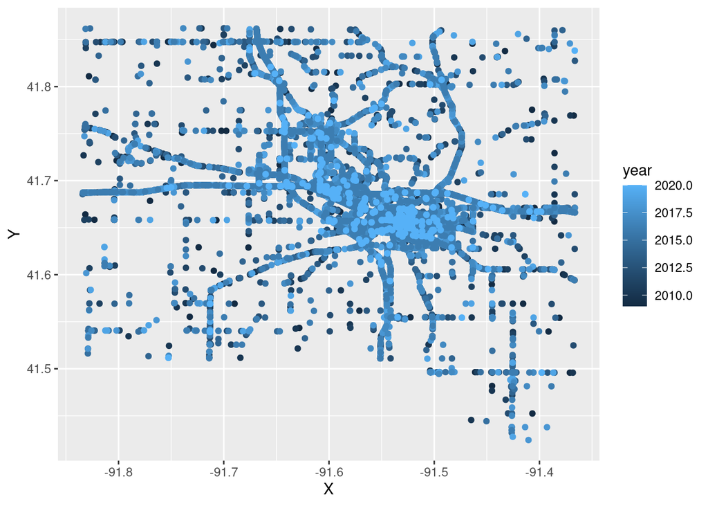

```r
# Lets look at some time data
crdt = crash_data %>% group_by(year)
crdt %>% ggplot(aes(x=X, y=Y, color=year)) + geom_point()
```

From this you can see that there are less accidents taking place outside of the city over time, and many more recent accidents from within the city. Except for on highways and major roadways.

```r
levels(crdt$DRUGALC)
```

```
## [1] "Under Influence of Alcohol/Drugs/Medications"
## [2] "Drug/Alcohol (Statutory)"
## [3] "Alcohol (Statutory)"
## [4] "Drug"
## [5] "Drug/Alcohol (< Statutory)"
## [6] "Alcohol (<Statutory)"
## [7] "Refused"
## [8] "None Indicated"
```

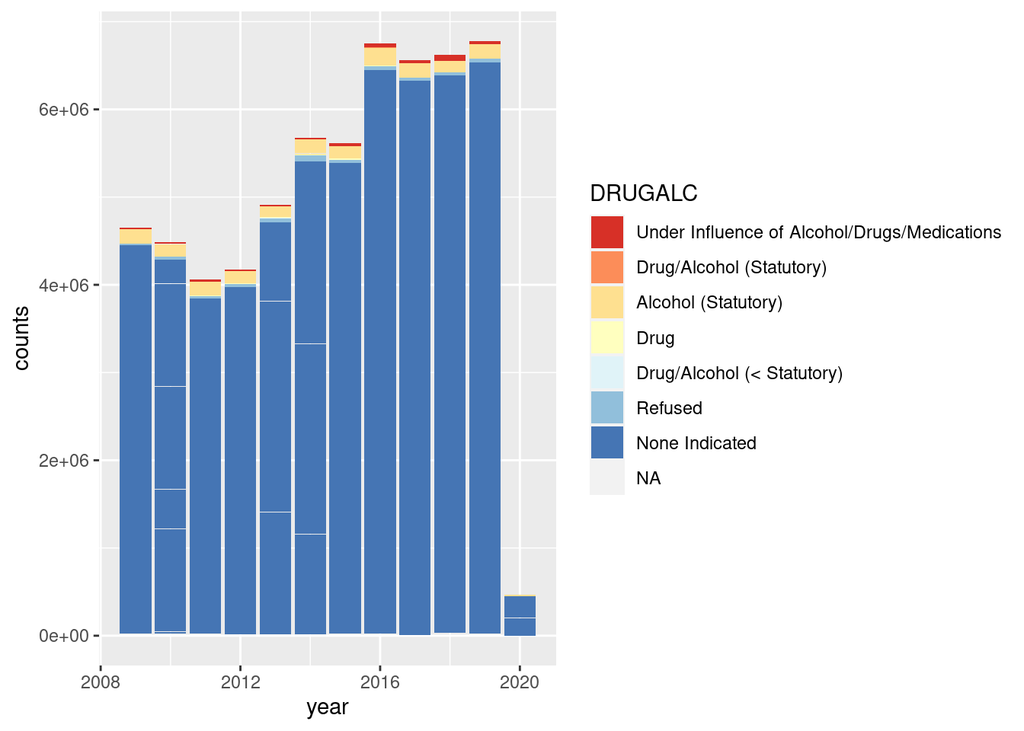

```r
counts = crdt %>% summarize(counts = n())
master = left_join(crdt, counts, by='year')
master %>% ggplot(aes(x=year, y=counts, fill=DRUGALC)) + geom_bar(stat='identity') + scale_fill_brewer(palette = 'RdYlBu')
```

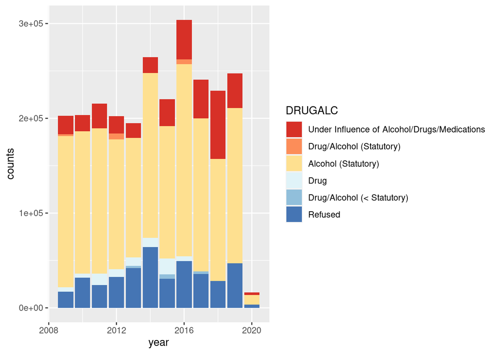

```r
film = master %>% filter(DRUGALC != 'None Indicated')
film %>% ggplot(aes(x=year, y=counts, fill=DRUGALC)) + geom_bar(stat='identity') + scale_fill_brewer(palette = 'RdYlBu')
```

You can also see that out of all cases, the vast majority of offenses stem from being over the limit for alcohol content.

And it would seem that the DOT may have been doing away with having separate types of classifications for drugs/alcohol, so we should merge those levels together to get an accurate result.

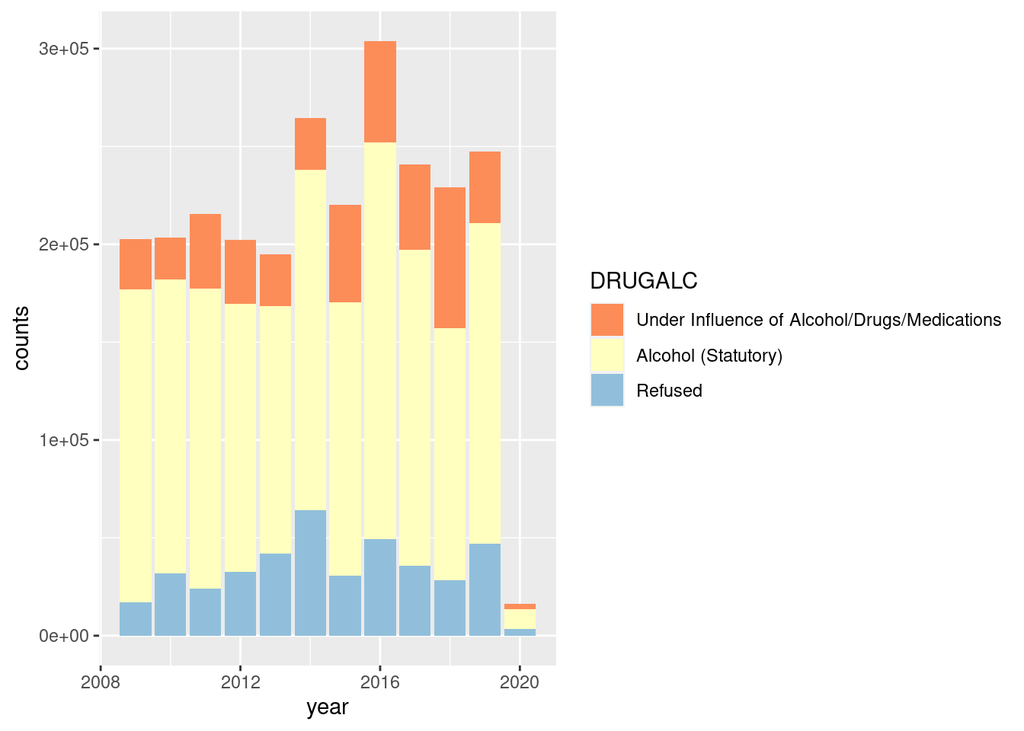

```r
levels(film$DRUGALC)[levels(film$DRUGALC) == 'Drug/Alcohol (Statutory)' | levels(film$DRUGALC) == 'Drug' | levels(film$DRUGALC) == 'Drug/Alcohol (< Statutory)'] = 'Under Influence of Alcohol/Drugs/Medications'
# levels(film$DRUGALC) = c('Under Influence of Alcohol/Drugs/Medications', 'Alcohol (Statutory)', 'Refused', 'None Indicated')

tcounts = film %>% group_by(year, DRUGALC) %>% summarize(tcount=n())
film = left_join(film, tcounts, by=c('year', 'DRUGALC')) %>% mutate(tperc = tcount/counts*100)

film %>% ggplot(aes(x=year, y=counts, fill=DRUGALC)) + geom_bar(stat='identity') + scale_fill_brewer(palette = 'RdYlBu')
```

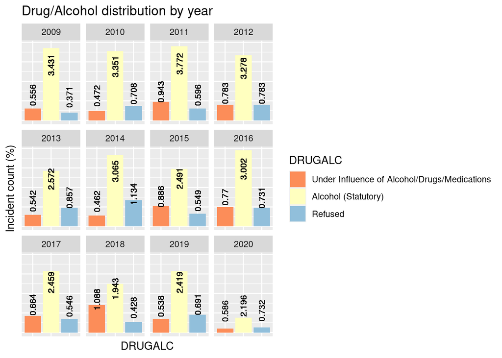

```r
film %>% ggplot(aes(x=DRUGALC, y=tcount, fill=DRUGALC, label=round(tperc, digits=3))) +
    facet_wrap(~year) +
    geom_bar(stat='identity', position='dodge') + scale_fill_brewer(palette='RdYlBu') +
    geom_text(aes(y=tcount / 2), nudge_y=20, color='black', srt=90, size=3) +
    theme(axis.text.y = element_blank(), axis.text.x = element_blank(), axis.ticks = element_blank()) +
    labs(y='Incident count (%)', title='Drug/Alcohol distribution by year')
```

```r
levels(crash_data$DRUGALC)[levels(crash_data$DRUGALC) == 'Drug/Alcohol (Statutory)' | levels(crash_data$DRUGALC) == 'Drug' | levels(crash_data$DRUGALC) == 'Drug/Alcohol (< Statutory)'] = 'Under Influence of Alcohol/Drugs/Medications'
```

## Visual Chloropleth Map

### Distribution of drug/alcohol usage

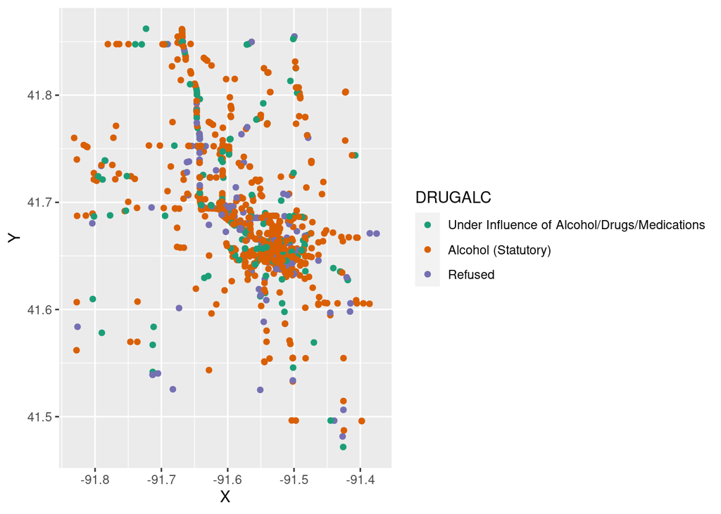

```r
crash_data_f = crash_data %>% filter(DRUGALC != 'None Indicated')
crash_data_f %>% ggplot(aes(x=X, y=Y, color=DRUGALC)) + geom_point() + scale_color_brewer(palette='Dark2')
```

This shows that there really isn’t a specific bias towards drug/alcohol usage with respect to location, it’s pretty evenly distributed. Though, it can be seen that more people refuse tests on the Highway (up/down)

### Distribution of car make usage

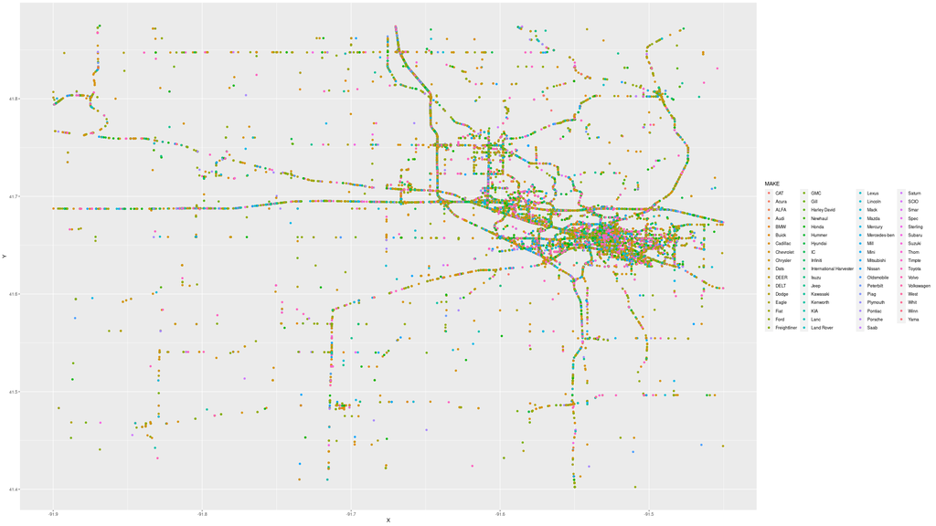

county plot

```r
png('./county_vehicle_plot.png', width = 1920, height = 1080)
crash_vehicle_data %>% filter(!is.na(MAKE)) %>% ggplot(aes(x=X, y=Y, color=MAKE)) + geom_point() # + scale_color_brewer(palette='Dark2')
dev.off()
```

This is an interesting plot, because it shows the distribution of types of cars around the county, towards the inside of the city you start to see a lot more GMC, Saturn, Suburu, Buick, whilst out in the country, you see a lot of Cadillac, Chevy, Ford, which makes sense, but one question I have is, can you tell where the poor district is juding by the price point of specific cars?

To do this, I’ll rearrange the general price range of each Make, along with any stereotypical use (trucking), and then look at the map again.

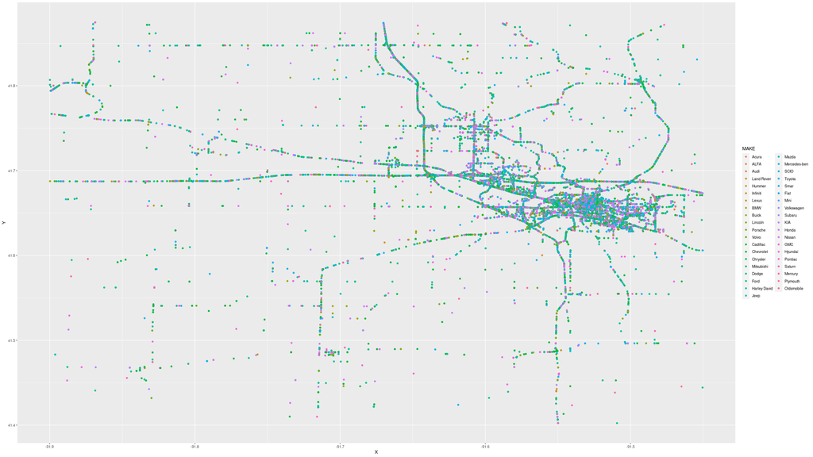

redlining map

```r
valid_makes = c('CAT', 'Acura', 'ALFA', 'Audi',
    'BMW', 'Buick',
    'Cadillac', 'Chevrolet', 'Chrysler',
    'Dats', 'DEER', 'DELT', 'Dodge',
    'Eagle',
    'Fiat', 'Ford', 'Freightliner',
    'GMC', 'Gill',
    'Harley David', 'Honda', 'Hummer', 'Hyundai',
    'IC', 'Infiniti', 'International Harvester', 'Isuzu',
    'Jaquar', 'Jeep',
    'Kawasaki', 'Kenworth', 'KIA',
    'Lanc', 'Land Rover', 'Lexus', 'Lincoln',
    'Mack', 'Mazda', 'Mercury', 'Mercedes-ben', 'Mini', 'Mill', 'Mitsubishi',
    'Newhaul', 'Nissan',
    'Oldsmobile',
    'Peterbilt', 'Piag', 'Plymouth', 'Pontiac', 'Porsche',
    'Saab', 'Saturn', 'SCIO', 'Smar', 'Spec', 'Sterling', 'Subaru', 'Suzuki',
    'Thom', 'Timpte', 'Toyota',
    'Volkswagen', 'Volvo',
    'West', 'Whit', 'Winn',
    'Yama')

valid_makes = c('Acura', 'ALFA', 'Audi', 'Land Rover', 'Hummer', 'Infiniti', 'Lexus',
    'BMW', 'Buick', 'Jaguar', 'Lincoln', 'Porsche', 'Volvo',
    'Cadillac', 'Chevrolet', 'Chrysler', 'Mitsubishi',
    'Dodge', 'Ford', 'Harley David', 'Jeep', 'Mazda', 'Mercedes-ben', 'SCIO', 'Toyota',
    'Smar', 'Fiat', 'Mini', 'Volkswagen', 'Subaru', 'KIA', 'Honda', 'Nissan',
    'GMC', 'Hyundai', 'Pontiac', 'Saturn', 'Mercury', 'Plymouth',
    'Oldsmobile')

levels(crash_vehicle_data$MAKE)[!levels(crash_vehicle_data$MAKE) %in% valid_makes] = NA
crash_vehicle_data$MAKE = factor(crash_vehicle_data$MAKE, levels=valid_makes)
png('./county_vehicle_plot_redlining.png', width = 1920, height = 1080)
crash_vehicle_data %>% filter(!is.na(MAKE)) %>% ggplot(aes(x=X, y=Y, color=MAKE)) + geom_point() # + scale_color_brewer(palette='Dark2')
dev.off()
```

### Most Dangerous Intersections

```r
png('./county_vehicle_plot_street.png', width = 1920, height = 1080)

streets = crash_data %>% mutate(total=X*X+Y*Y)

scnt = streets %>%
    group_by(total) %>%
    summarize(count = n())

streets = streets %>%
    left_join(scnt, by='total') %>%
    arrange(desc(count))

str(streets %>% distinct(LITERAL, .keep_all=TRUE))
```

```
## 'data.frame':    2197 obs. of  39 variables:
##  $ X          : num  -91.5 -91.5 -91.6 -91.5 -91.5 ...
##  $ Y          : num  41.7 41.6 41.7 41.7 41.6 ...
##  $ CRASH_KEY  : int  2009001713 2009003206 2009006959 2009009025 2009003212 2013024265 2009003847 2009015704 2009010420 2009003745 ...
##  $ CASENUMBER : int  2009486058 2009488102 2009492819 2009495227 2009488110 2013748678 2009488936 2009503091 2009496841 2009488782 ...
##  $ LECASENUM  : num  4466 4343 183 1 4479 ...
##  $ year       : num  2009 2009 2009 2009 2009 ...
##  $ day        : num  4 15 14 13 14 14 25 14 20 15 ...
##  $ CRASH_MONTH: Factor w/ 12 levels "April","August",..: 5 5 4 4 5 6 5 1 4 5 ...
##  $ CRASH_DAY  : Factor w/ 7 levels "Friday","Monday",..: 4 5 3 1 7 4 4 6 1 5 ...
##  $ hour       : num  1 8 12 17 10 19 11 16 11 16 ...
##  $ minute     : num  30 30 30 40 50 1 51 30 26 58 ...
##  $ SYSTEMSTR  : Factor w/ 8 levels "","I-380","I-80",..: 4 8 3 8 8 8 1 4 8 4 ...
##  $ LITERAL    : chr  "IA 1/E BURLINGTON ST & S GILBERT ST" "US 6 & SYCAMORE ST" "I-80 & IA 965/CORAL RIDGE AVE & COMMERCE DR" "US 6/S RIVERSIDE DR & IA 1/W BURLINGTON ST & GRAND AVE" ...
##  $ FRSTHARM   : Factor w/ 58 levels "1","11","13",..: 36 43 43 43 43 43 43 43 43 43 ...
```

[output cut: 25 more lines]

```r
head(unique(streets$LITERAL), 10)
```

```
##  [1] "IA 1/E BURLINGTON ST & S GILBERT ST"
##  [2] "US 6 & SYCAMORE ST"
##  [3] "I-80 & IA 965/CORAL RIDGE AVE & COMMERCE DR"
##  [4] "US 6/S RIVERSIDE DR & IA 1/W BURLINGTON ST & GRAND AVE"
##  [5] "US 6 & S GILBERT ST"
##  [6] "US 6 & IA 1/E BURLINGTON ST & S GILBERT ST"
##  [7] "MORMON TREK BLVD & MELROSE AVE"
##  [8] "IA 1/IOWA 1 & MORMON TREK BLVD"
##  [9] "US 6/2ND ST & CAMP CARDINAL BLVD & 22ND AVE"
## [10] "IA 1/W BURLINGTON ST/E BURLINGTON ST & S MADISON ST"
```

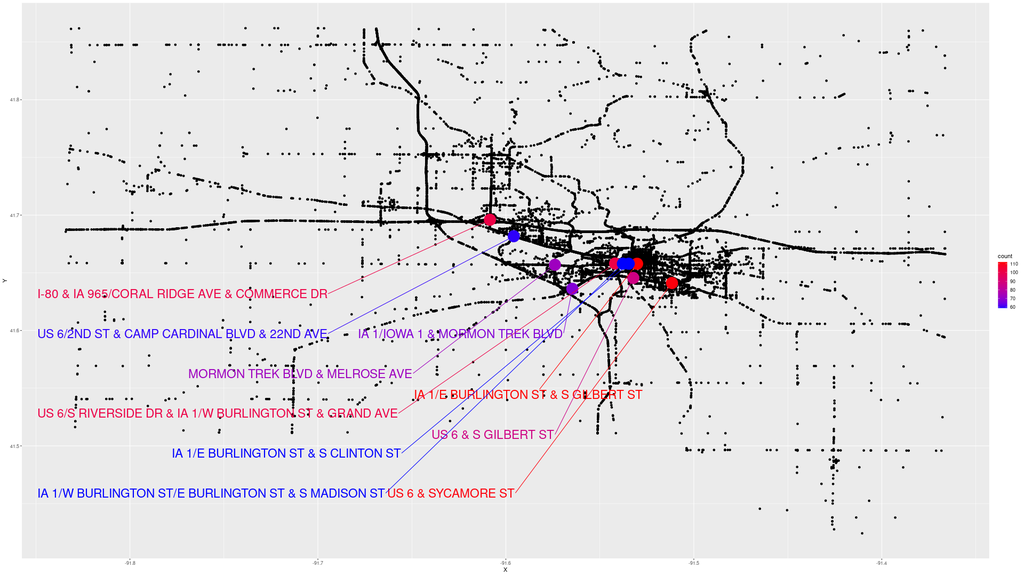

street analysis

```r
topstreets = streets %>%
    distinct(total, .keep_all=TRUE) %>%
    distinct(LITERAL, .keep_all=TRUE) %>%
    filter(LITERAL %in% head(LITERAL, 10))

topstreets %>% ggplot(aes(x=X, y=Y, label=LITERAL)) +
    geom_point(data=crash_data, aes(x=X, y=Y), show.legend=FALSE) +
    geom_point(aes(color=count), size=10) + geom_text_repel(aes(color=count), size=8, nudge_y=-0.1, nudge_x=-0.2, label.padding=2, box.padding=2, show.legend=FALSE) +
    scale_color_gradient(low='blue', high='red')
dev.off()
```

Here is an image of the top 10 most frequently accidented intersections in Johnson County

#### Breakdown of types of accidents at the most frequented intersections

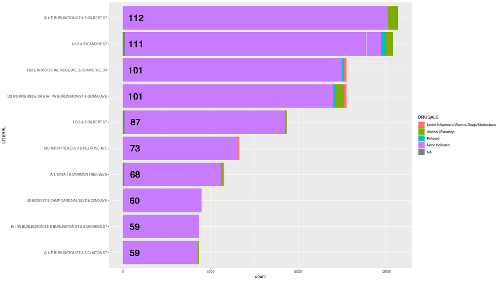

street distribution

```r
png('./county_street_dist.png', width = 1280, height = 720)
streets %>% filter(LITERAL %in% topstreets$LITERAL & count >= 50) %>% mutate(LITERAL = factor(LITERAL, levels=rev(unique(LITERAL)))) %>%
    ggplot(aes(x=LITERAL, y=count, label=count, fill=DRUGALC)) +
        geom_bar(stat='identity') +
        scale_color_brewer(palette='Dark2') + coord_flip() +
        geom_text(size=8, nudge_y=500)
dev.off()
```